# Seasonal Package Primer with Hands-on Examples

Brian C. Monsell

4/7/2022

# Outline

- Seasonal Package Basics
- Running One Series
- Running Multiple Series
- Examples
- Resources

# I expect that you

- Know a little about R
  - lists and time series (`ts`) objects
- Know a little about running X-13ARIMA-SEATS
  - input and output files

# Seasonal Package

- Run X-13ARIMA-SEATS within R
- Developed by Christophe Sax
- Reduces reliance on external files

# X-13ARIMA-SEATS Input Files

- Data Files
- Input Specification Files
- User defined Regression and Prior Adjustment Factors
- Metafiles

# X-13ARIMA-SEATS Output Files

- Output
- Graphics
- Saved tables
- Diagnostics (UDG and Log)
- Error

# X-13ARIMA Spec File

```
series{
  title="International Airline Passengers "
  start=1949.01   file = "airline.txt"
}
transform{ function=auto }
estimate{ }
regression{ aictest=(td easter) }
arima{  model = (0 1 1)(0 1 1)  }
outlier{ }
x11{ save = (d10 d11 d12 d13 d16 e18) }
spectrum{ }
```

# Example

```r
# run Airline Series,
# X-11 seasonal adjustment

m_air <-
    seasonal::seas(AirPassengers, x11="",
                   arima.model="(0 1 1)(0 1 1)")
```

# Equivalent spec file

```
 series{
   title = "iofile"
   file = "C:\Users\MONSEL~1\AppData\Local\Temp\RtmpE3tzrP\x1332243080443e/iofile.dta"
   format = "datevalue"
   period = 12
 }

 transform{
   function = auto
   print = aictransform
 }

 regression{
   aictest = (td easter)
 }

 outlier{

 }

 x11{
   save = (d10 d11 d12 d13 d16 e18)
 }

 arima{
   model = (0 1 1)(0 1 1)
 }

 estimate{
   save = (model estimates residuals)
 }

 spectrum{
   print = qs
 }
```

# Specifying Arguments in ‘seas’

To set a specific argument from an X-13ARIMA-SEATS specification, use

```
specname.argument = value
```

Examples:

```
arima.model = “(0 1 1)(0 1 1)”
forecast.maxlead = 60
x11.siglim = c(1.5, 3.0)
```

# Default settings for `seas`

- Automatic transformation identification
- Automatic model identification
- Automatic outlier identification
- AICC tests for trading day, Easter regressors
- SEATS seasonal adjustment

# Override default settings

- Specify transformation
  - `transform.function = “log”`
- Set `outlier = NULL`
- Set `regression.aictest = NULL`
- Specify an ARIMA model
  - `arima.model = “(0 1 1)(0 1 1)”`
- Specify an X-11 argument or set `x11 = “ “`

# Difference between NULL and " "

`outlier = “ “`  
Use the empty spec – `outlier{ }`

`outlier = NULL`  
Do not include `outlier` spec in run

# Read in data from an external file

- `import.ts` function
  - Reads data from external files in datevalue format (default)
  - Output is a ts object

# import.ts example

```r
# read unemployed males 16-19
n3000013 <-
   seasonal::import.ts("data/n3000013.dat")

n3000013
```

```
##          Jan     Feb     Mar     Apr     May     Jun     Jul     Aug     Sep
## 2003  695431  733383  699819  645713  667113  987408  901908  613867  650764
## 2004  630389  610103  634629  627053  632549  862728  788557  654616  597802
## 2005  628017  731657  721733  694984  681699  902827  797928  635640  552295
## 2006  560935  634380  621861  563405  582838  881897  778662  625214  600480
## 2007  561473  618733  567521  554621  601696  891656  710239  596907  601184
## 2008  720591  648252  580248  535039  751733  988680 1012461  701500  690326
## 2009  777513  855569  801286  764219  887845 1140294 1088208  959590  897972
## 2010  907956  850990  875242  803920  819416 1093705 1035588  881575  783044
## 2011  810169  734515  723074  712955  719944 1012211  930052  854967  761827
## 2012  707578  739021  715657  726151  752767 1032330  968566  880670  765714
## 2013  748245  757969  670801  662879  757238 1090524  974496  766863  712462
## 2014  591100  621685  629982  505464  542388  869489  780979  624821  603475
## 2015  559028  493236  543018  440738  581488  800859  615202  517034  461072
## 2016  481689  479077  479472  393689  454861  739598  609206  564901  481824
```

[output cut: 25 more lines]

# Seasonally adjusting one series

- `seas` function
  - Generates the seasonal adjustment based on the options provided
- Output is a seas object, a list object that contains
  - input
  - diagnostics
  - output

# seas example

```r
# seasonally adjust n3000013
n3000013_seas <- seasonal::seas(n3000013,
    series.span = "2003.1,",
    arima.model = "(0 1 1)(0 1 1)", forecast.maxlead = 60,
    estimate.exact = "arma", estimate.maxiter = 10000,
    check.print = c("none", "+acf", "+acfplot",
                    "+normalitytest"),
    regression.aictest = NULL, outlier.types = "all",
    regression.variables = c("ls2008.may", "tc2020.apr"))
```

# out function

- Shows output from seasonal adjustment run in a browser

```r
seasonal::out(n3000013_seas)
```

# Structure of the seas object

```r
names(n3000013_seas)
```

```
##  [1] "series" "udg"    "data"   "err"    "est"    "model"  "wdir"   "iofile"
##  [9] "call"   "list"   "x"      "spc"
```

# Seas Functions: Data Extraction

- `seasonal::final`
  - Extracts final seasonal adjustment
- `seasonal::trend`
  - Extracts final trend component
- `seasonal::series`
  - Extracts saved series from seas object
  - Specify either a table name (`“seasonal”`) or table abbreviation (`“d10”`)
  - If table not in the seas object, ‘seas’ will be reevaluated
- List of all importable tables from X-13ARIMA-SEATS
  - `?seasonal::series`

# Seas Functions: Data Extraction

```r
# extract final seasonal adjustment
n3000013_sa    <- seasonal::final(n3000013_seas)
n3000013_trend <- seasonal::trend(n3000013_seas)
head(cbind(n3000013_seas$x, n3000013_sa, n3000013_trend))
```

```
##      n3000013_seas$x n3000013_sa n3000013_trend
## [1,]          695431    729572.2       735217.5
## [2,]          733383    746962.6       733016.0
## [3,]          699819    735375.6       728126.8
## [4,]          645713    726884.8       720115.9
## [5,]          667113    692314.9       711889.0
## [6,]          987408    724390.9       704597.1
```

```r
# extract SEATS seasonal factors
n3000013_sf    <- seasonal::series(n3000013_seas, "s10")
head(n3000013_sf)
```

```
## [1] 0.9532039 0.9818202 0.9516483 0.8883293 0.9635976 1.3630873
```

# Plot of Seasonal Factors

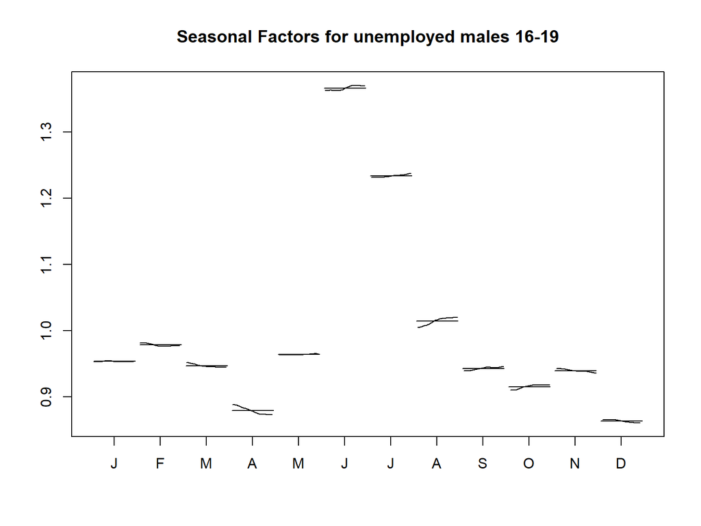

```r
monthplot(n3000013_sf, ylab = " ",
          main = "Seasonal Factors for unemployed males 16-19")
```

# Plot of ori, SA, trend

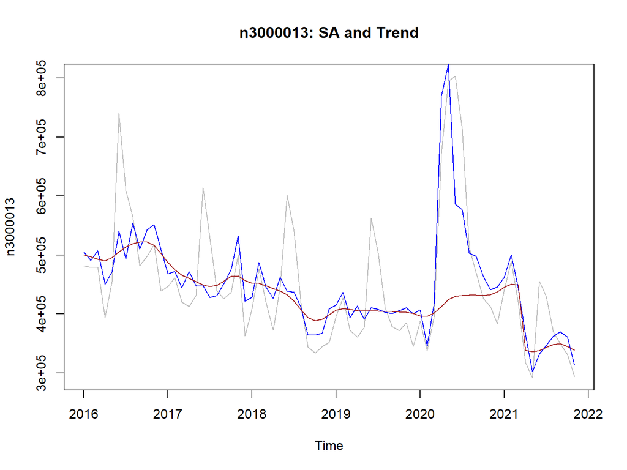

```r
this_x     <- window(n3000013_seas$x, start = c(2016, 1))
this_sa    <- window(n3000013_sa, start = c(2016, 1))
this_trend <- window(n3000013_trend, start = c(2016, 1))
plot(this_x, main = "n3000013: SA and Trend", ylab = "n3000013",
     col = "grey")
lines(this_sa, col = "blue")
lines(this_trend, col = "brown")
```

# Seas Object: Diagnostics

- `n3000013_seas$udg`
  - Contains output from X-13ARIMA-SEATS `udg` file
  - “Unified Diagnostics File”
  - `keyword: value` structure

# Example UDG File

```
date: Sep 22, 2016
time: 09.07.36
version: 1.1
build: 34
output: html
srstit: X-13ARIMA-SEATS run of airline
srsnam: airline
freq:    12
span:  1st month,1949 to 12th month,1960
constant:     0.0000000000E+00
transform: Log(y)
nfcst:    60
ciprob:     0.950000
lognormal: no
mvval:     0.1000000000E+10
iqtype: ljungbox
samode: multiplicative seasonal adjustment
```

# udg Function

```r
names(seasonal::udg(n3000013_seas))
```

```
##   [1] "date"                       "time"
##   [3] "version"                    "build"
##   [5] "output"                     "srstit"
##   [7] "srsnam"                     "freq"
##   [9] "span"                       "nobs"
##  [11] "constant"                   "transform"
##  [13] "nfcst"                      "ciprob"
##  [15] "lognormal"                  "mvval"
##  [17] "iqtype"                     "samode"
##  [19] "spectrum"                   "startspec"
##  [21] "spectype"                   "decibel"
##  [23] "specrobustsa"               "specseries"
##  [25] "showseasonalfreq"           "specmaxar"
##  [27] "altfreq"                    "saveallspecfreq"
##  [29] "nspecfreq"                  "ntdfreq"
```

[output cut: 143 more lines]

# udg Function: Examples

```r
seasonal::udg(n3000013_seas,"nfcst")
```

```
## nfcst
##    60
```

```r
seasonal::udg(n3000013_seas,"spectype")
```

```
##      spectype
## "AR-spectrum"
```

```r
seasonal::udg(n3000013_seas,"qsori")
```

```
##         qsori
## [1,] 214.4249
## [2,]   0.0000
```

```r
as.vector(seasonal::udg(n3000013_seas,"qsori"))
```

```
## [1] 214.4249   0.0000
```

```r
n3000013_seas$udg[["nreg"]]
```

```
## [1] "3"
```

```r
seasonal::udg(n3000013_seas,"nreg")
```

```
## nreg
##    3
```

# Import spec files: import.spc

```r
# import seasonal options from specification file

n3000013_import_spc <-
    seasonal::import.spc("n3000013.spc")

names(n3000013_import_spc)
```

```
## [1] "x"    "seas"
```

# Import spec files: import.spc

```r
# import seasonal options from specification file

n3000013_import_spc <-
    seasonal::import.spc("n3000013.spc")

names(n3000013_import_spc)
```

```
## [1] "x"    "seas"
```

```r
n3000013_import_spc$x
```

```
## x <- import.ts("X:/talks/RPrimer_April2022/data/n3000013.dat")
```

```r
n3000013_import_spc$seas
```

```
## seas(x = x, series.span = "2003.1,", series.precision = 5, series.decimals = 2,
##     series.missingcode = 0, transform.function = "none", regression.variables = c("ls2008.may",
##     "tc2020.apr"), arima.model = "(0 1 1)(0 1 1)", estimate.exact = "arma",
##     estimate.maxiter = 10000, forecast.maxlead = 60, check.print = c("none",
##     "+acf", "+acfplot", "+normalitytest"), x11.seasonalma = "s3x9",
##     x11.trendma = 13, automdl = NULL, outlier = NULL, regression.aictest = NULL)
```

# Import spec files: import.spc

```r
# evaluate separate elements of n3000013_import_spc
library(seasonal)

eval(n3000013_import_spc$x)
n3000013_seas_from_file <-
   eval(n3000013_import_spc$seas)

names(n3000013_seas_from_file)
```

```
##  [1] "series" "udg"    "data"   "err"    "est"    "model"  "wdir"   "iofile"
##  [9] "call"   "list"   "x"      "spc"
```

# Running More Than One Series

- Can use list or mts (multiple time series) objects
- Run the `seas` function on the object
  - Old way: lists with the ‘lapply’ function
  - New way: process lists and mts objects directly

# Running More Than One Series

```r
# create list of UN components
#   n3000013 - unemployed males 16-19
#   n3000014 - unemployed women 16-19
#   n3000025 - unemployed males 20+
#   n3000026 - unemployed women 20+

UN_data_list <-
   list(n3000013 = n3000013,
        n3000014 = seasonal::import.ts("data/n3000014.dat"),
        n3000025 = seasonal::import.ts("data/n3000025.dat"),
        n3000026 = seasonal::import.ts("data/n3000026.dat"))

#
# UN_data_list$n3000013 and
# UN_data_list[[1]] are equivalent
#
```

# Running More Than One Series

```r
UN_airline_seas <-
    seasonal::seas(UN_data_list, x11 = "",
        check.print = c("none", "+acf", "+acfplot",
                        "+normalitytest"),
        regression.aictest = NULL,
        outlier.types = "all",
        arima.model = "(0 1 1)(0 1 1)")

names(UN_airline_seas)
```

```
## [1] "n3000013" "n3000014" "n3000025" "n3000026"
```

# Running More than One Series

- Output is a list of seas objects
  - Elements have the same names as the list object
- To extract output or diagnostics, you can
  - Apply functions to the individual elements
  - Use `lapply` or `for` loops on the list as a whole

# Examples

- Get transformation information from list of objects
- Specify options for individual series using `list` argument
- Using mts objects with `seasonal`
- Composite seasonal adjustment with `seasonal`
- `out` argument
- User defined regressors with `seasonal`
- Saving regARIMA model summaries

# Transformation Choice

```r
UN_names <- names(UN_data_list)

# get transformation choice, AICC

UN_AICC_nolog  <-
   lapply(UN_airline_seas, function(x)
          try(seasonal::udg(x, "aictest.trans.aicc.nolog")))
UN_AICC_log    <-
   lapply(UN_airline_seas, function(x)
          try(seasonal::udg(x, "aictest.trans.aicc.log")))
UN_AICC_trans  <-
   lapply(UN_airline_seas, function(x)
          try(seasonal::udg(x, "aictrans")))

# Generate difference between log and no log AICC
UN_AICC_diff   <- list()

for (i in 1:length(UN_names)) {
    this_series <- UN_names[i]
    UN_AICC_diff[[this_series]] <-
        UN_AICC_log[[this_series]] - UN_AICC_nolog[[this_series]]
}
```

# Transformation Choice

```r
# collect items into a data frame
UN_AICC_df <-
    data.frame(nolog = unlist(UN_AICC_nolog),
               log = unlist(UN_AICC_log),
               diff  = unlist(UN_AICC_diff),
               trans = unlist(UN_AICC_trans))
rownames(UN_AICC_df) <- UN_names

UN_AICC_df
```

```
##             nolog      log        diff             trans
## n3000013 5316.596 5318.918    2.321397 No transformation
## n3000014 5355.137 5309.089  -46.048193            Log(y)
## n3000025 6281.672 6146.667 -135.005170            Log(y)
## n3000026 6327.868 6147.386 -180.482722            Log(y)
```

# Using mts Objects

```r
# An alternate approach - using mts objects

UN_data_mts <-
  cbind(n3000013,
        UN_data_list$n3000014,
        UN_data_list$n3000025,
        UN_data_list$n3000026)
colnames(UN_data_mts) <- names(UN_data_list)

UN_airline_mts_seas <-
    seasonal::seas(UN_data_mts, x11 = "",
        check.print = c("none", "+acf", "+acfplot",
                        "+normalitytest"),
        regression.aictest = NULL,
        outlier.types = "all",
        arima.model = "(0 1 1)(0 1 1)")

names(UN_airline_mts_seas)
```

```
## [1] "n3000013" "n3000014" "n3000025" "n3000026"
```

# Specifying options for each series

```r
UN_individual_seas <-
  seasonal::seas(UN_data_mts,
    x11 = "",
    check.print = c("none", "+acf", "+acfplot", "+normalitytest"),
    regression.aictest = NULL,
    outlier.types = "all",
    arima.model = "(0 1 1)(0 1 1)",
    list = list(
        list(transform.function = "none"),
        list(transform.function = "log"),
        list(transform.function = "log"),
        list(transform.function = "log")
    )
)
names(UN_individual_seas)
```

```
## [1] "n3000013" "n3000014" "n3000025" "n3000026"
```

# Another alternate approach

```r
# An alternate approach - specifiying time series within the list

UN_auto_x11_seas <-
  seasonal::seas(
    check.print = c("none", "+acf", "+acfplot", "+normalitytest"),
    regression.aictest = NULL,
    outlier.types = "all",
    x11.seasonalma = "s3x5",
    list = list(
        list(x = UN_data_list$n3000013, transform.function = "none"),
        list(x = UN_data_list$n3000014, transform.function = "log"),
        list(x = UN_data_list$n3000025, transform.function = "log"),
        list(x = UN_data_list$n3000026, transform.function = "log")
    )
)

names(UN_auto_x11_seas)
```

```
## [1] "ser_1" "ser_2" "ser_3" "ser_4"
```

```r
names(UN_auto_x11_seas) <- names(UN_data_list)
names(UN_auto_x11_seas)
```

```
## [1] "n3000013" "n3000014" "n3000025" "n3000026"
```

```r
lapply(UN_auto_x11_seas, function(x) try(seasonal::udg(x, "automdl")))
```

```
## $n3000013
##          automdl
## "(0 1 1)(0 1 1)"
##
## $n3000014
##          automdl
## "(0 1 1)(0 1 1)"
##
## $n3000025
##          automdl
## "(0 2 1)(0 1 1)"
##
## $n3000026
##          automdl
## "(3 1 1)(0 1 1)"
```

# Composite seasonal adjustment

- Two components - A and B
- Indirect adjustment: SA(A) + SA(B)
- Direct adjustment: SA(A + B)

# Composite seasonal adjustment in seasonal package

```r
UN_composite_seas <- seasonal::seas(UN_data_mts,
     x11 = "",
     check.print = c("none", "+acf", "+acfplot", "+normalitytest"),
     regression.aictest = NULL,
     outlier.types = "all",
     arima.model = "(0 1 1)(0 1 1)",
     series.comptype = "add",
     list = list(
         list(transform.function = "none"),
         list(transform.function = "log"),
         list(transform.function = "log"),
         list(transform.function = "log")
     ),
     composite =
       list(arima.model = "(0 1 1)(0 1 1)", x11 = "",
            check.print = c("none", "+acf", "+acfplot", "+normalitytest"),
       regression.aictest = NULL,
       outlier.types = "all")
)

names(UN_composite_seas)
```

```
## [1] "n3000013"  "n3000014"  "n3000025"  "n3000026"  "composite"
```

# A Note About Composite Adjustment

- Some `seasonal` functions do not have access to `composite` element
  - out
  - series
- Will be in the next build of seasonal

# The out argument

```r
UN_composite_out_seas <- seasonal::seas(UN_data_mts,
     x11 = "",
     check.print = c("none", "+acf", "+acfplot", "+normalitytest"),
     regression.aictest = NULL,
     outlier.types = "all",
     arima.model = "(0 1 1)(0 1 1)",
     series.comptype = "add",
     list = list(
         list(transform.function = "none"),
         list(transform.function = "log"),
         list(transform.function = "log"),
         list(transform.function = "log")
     ),
     composite =
       list(arima.model = "(0 1 1)(0 1 1)", x11 = "",
            check.print = c("none", "+acf", "+acfplot", "+normalitytest"),
       regression.aictest = NULL,
       outlier.types = "all"),
     out = TRUE
)

tf <- tempfile(fileext = ".html")
writeLines(UN_composite_out_seas$composite$out, tf)
browseURL(tf)
```

# The out argument

```r
m_air_out <- seasonal::seas(AirPassengers,
                    x11="", out = TRUE,
                    arima.model="(0 1 1)(0 1 1)")

names(m_air)
```

```
##  [1] "series" "udg"    "data"   "err"    "est"    "model"  "wdir"   "iofile"
##  [9] "call"   "list"   "x"      "spc"
```

```r
names(m_air_out)
```

```
##  [1] "series" "udg"    "data"   "err"    "est"    "model"  "out"    "wdir"
##  [9] "iofile" "call"   "list"   "x"      "spc"
```

```r
object.size(m_air)
```

```
## 95288 bytes
```

```r
object.size(m_air_out)
```

```
## 433216 bytes
```

```r
head(m_air_out$out, n=10)
```

```
##  [1] "<!DOCTYPE html PUBLIC \"-//W3C//DTD HTML 4.01 Transitional//EN\""
##  [2] "   \"http://www.w3.org/TR/html4/loose.dtd\">"
##  [3] "<html lang=\"en\">"
##  [4] "<head>"
##  [5] "<title>x1349242eba6714/iofile.html</title>"
##  [6] "<meta name=\"keywords\"  content=\"seasonal adjustment, X-13ARIMA-SEATS, regARIMA modeling\">  "
##  [7] "<meta name=\"description\"  content=\"X-13ARIMA-SEATS Output File (x1349242eba6714/iofile.html)\">  "
##  [8] "<meta name=\"generator\"  content=\"X-13ARIMA-SEATS\">  "
##  [9] "<meta name=\"author\"  content=\"Time Series Research Staff, CSRM, US Census Bureau\">  "
## [10] "<meta http-equiv=\"Content-Type\"  content=\"text/html; charset=ISO-8859-1\">  "
```

# Adding User Defined Regressors

```r
start_reg <- c(2003, 1)
end_reg   <- c(2030,12)
tc_2020_apr_p9 <-
    sautilities::gen_tc_outlier_ts(c(2020,4), start_reg, end_reg,
                                   tc_alpha = 0.9)
tc_2020_apr_p7 <-
    sautilities::gen_tc_outlier_ts(c(2020,4), start_reg, end_reg,
                                   tc_alpha = 0.7)

n3000013_final_seas_tc_p9 <-
    seasonal::seas(x = n3000013, xreg = tc_2020_apr_p9,
                   regression.usertype = c("ls"),
                   transform.function = "none",
                   regression.variables = c("ls2008.may", "ls2021.Apr"),
                   arima.model = "(0 1 1)(0 1 1)",
                   estimate.exact = "arma", estimate.maxiter = 10000,
                   forecast.maxlead = 60,
                   check.print = c("none", "+acf", "+acfplot",
                                   "+normalitytest"),
                   seats.save = c("s14", "mdc"),
                   regression.aictest = NULL,
                   outlier = NULL)

n3000013_final_seas_tc_p7 <-
    seasonal::seas(x = n3000013, xreg = tc_2020_apr_p7,
                   regression.usertype = c("ls"),
                   transform.function = "none",
                   regression.variables = c("ls2008.may", "ls2021.Apr"),
                   arima.model = "(0 1 1)(0 1 1)",
                   estimate.exact = "arma", estimate.maxiter = 10000,
                   forecast.maxlead = 60,
                   check.print = c("none", "+acf", "+acfplot",
                                   "+normalitytest"),
                   seats.save = c("s14", "mdc"),
                   regression.aictest = NULL,
                   outlier = NULL)

n3000013_tc_AICC <-
    as.numeric(c(seasonal::udg(n3000013_final_seas_tc_p9, "aicc"),
                 seasonal::udg(n3000013_final_seas_tc_p7, "aicc")))
n3000013_tc_AICC
```

```
## [1] 5243.561 5241.824
```

# Plot of ori, SA, trend

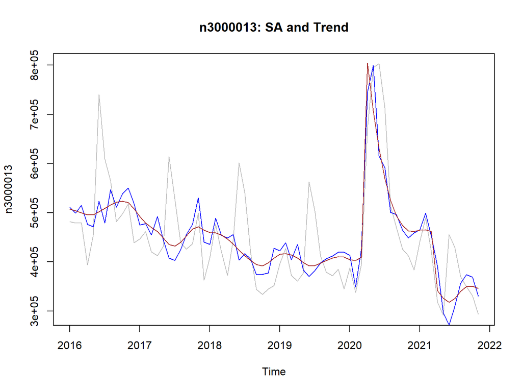

```r
this_x            <- window(n3000013_final_seas_tc_p7$x, start = c(2016, 1))
n3000013_sa_p7    <- seasonal::final(n3000013_final_seas_tc_p7)
this_sa_p7        <- window(n3000013_sa_p7, start = c(2016, 1))
n3000013_trend_p7 <- seasonal::trend(n3000013_final_seas_tc_p7)
this_trend_p7     <- window(n3000013_trend_p7, start = c(2016, 1))
plot(this_x, main = "n3000013: SA and Trend", ylab = "n3000013",
     col = "grey")
lines(this_sa_p7, col = "blue")
lines(this_trend_p7, col = "brown")
```

# Adding User Defined Regressors

```r
n3000013_tc_seas <-
    seasonal::seas(x = cbind(n3000013, n3000013),
                   regression.usertype = c("ls"),
                   transform.function = "none",
                   regression.variables = c("ls2008.may", "ls2021.Apr"),
                   arima.model = "(0 1 1)(0 1 1)",
                   estimate.exact = "arma", estimate.maxiter = 10000,
                   forecast.maxlead = 60,
                   check.print = c("none", "+acf", "+acfplot",
                                   "+normalitytest"),
                   seats.save = c("s14", "mdc"),
                   regression.aictest = NULL,
                   outlier = NULL,
                   list = list(
                      list(xreg = tc_2020_apr_p9),
                      list(xreg = tc_2020_apr_p7)))

names(n3000013_tc_seas) <- c("n3000013_p9", "n3000013_p7")

lapply(n3000013_tc_seas, function(x) try(seasonal::udg(x, "aicc")))
```

```
## $n3000013_p9
##     aicc
## 5243.561
##
## $n3000013_p7
##     aicc
## 5241.824
```

# Save regARIMA model summaries

```r
sautilities::get_regarima_estimates_matrix(n3000013_final_seas_tc_p7,
                                           add_diff = TRUE,
                                           this_xreg_names = "TC2020.4 (alpha=0.7)")
```

```
##                        Coefficient      Std_Err   T-value
## LS2008.may            1.501824e+05 3.907703e+04  3.843241
## LS2021.Apr           -1.105492e+05 4.209504e+04 -2.626180
## TC2020.4 (alpha=0.7)  3.793144e+05 4.310564e+04  8.799645
## Nonseasonal_Diff      1.000000e+00 0.000000e+00  0.000000
## Seasonal_Diff         1.000000e+00 0.000000e+00  0.000000
## MA_Nonseasonal_01_01  5.019325e-01 5.772374e-02  8.695427
## MA_Seasonal_12_12     7.779148e-01 4.819239e-02 16.141860
```

```r
sautilities::get_regarima_estimates_matrix(n3000013_final_seas_tc_p9,
                                           add_diff = TRUE,
                                           this_xreg_names = "TC2020.4 (alpha=0.9)")
```

```
##                        Coefficient      Std_Err   T-value
## LS2008.may            1.532357e+05 4.007305e+04  3.823908
## LS2021.Apr           -7.388277e+04 4.475191e+04 -1.650941
## TC2020.4 (alpha=0.9)  3.709631e+05 4.366319e+04  8.496014
## Nonseasonal_Diff      1.000000e+00 0.000000e+00  0.000000
## Seasonal_Diff         1.000000e+00 0.000000e+00  0.000000
## MA_Nonseasonal_01_01  4.603411e-01 5.944591e-02  7.743864
## MA_Seasonal_12_12     7.546847e-01 5.066026e-02 14.896977
```

# References

- Seasonal Adjustment by X-13ARIMA-SEATS in R by Chistophe Sax and Dick Eddelbuettel
  - Excellent introduction
  - Details of a graphical user interface
  - Large scale production use
  - `x13binary` package

https://cran.r-project.org/web/packages/seasonal/vignettes/seas.pdf

# References

- Adjusting Multiple Series
  - Covers all aspects of the topic
  - Details of the multimode argument

https://cran.r-project.org/web/packages/seasonal/vignettes/multiple.html

# References

- Examples of X-13ARIMA SEATS in R
  - Gives every example from the X-13ARIMA-SEATS Manual
- For each example
  - X-13 code
  - Equivalent seasonal code
  - Remarks on the implementation
  - Allow you to run it yourself

http://www.seasonal.website/examples.html

# Thank you for your time

Brian C. Monsell  
OEUS  
monsell.brian@bls.gov

# Appendix: seas Object Structures

- Input structures
- Data structures
- Model structures

# Input, seas object

`n3000013_seas$spc`

- Spec file used in the seas run
- Spec input is stored as a list

`n3000013_seas$call`

- Preserves the call to seasonal

# input structures, seas object

```r
names(n3000013_seas$spc)
```

```
##  [1] "series"     "transform"  "seats"      "regression" "outlier"
##  [6] "arima"      "forecast"   "estimate"   "check"      "spectrum"
```

```r
n3000013_seas$spc$regression
```

```
## $variables
## [1] "ls2008.may" "tc2020.apr"
```

```r
n3000013_seas$spc$arima
```

```
## $model
## [1] "(0 1 1)(0 1 1)"
```

# input structures, seas object

```r
n3000013_seas$call
```

```
## seasonal::seas(x = n3000013, regression.aictest = NULL, series.span = "2003.1,",
##     arima.model = "(0 1 1)(0 1 1)", forecast.maxlead = 60, estimate.exact = "arma",
##     estimate.maxiter = 10000, check.print = c("none", "+acf",
##         "+acfplot", "+normalitytest"), outlier.types = "all",
##     regression.variables = c("ls2008.may", "tc2020.apr"))
```

# Data structures, seas object

```r
names(n3000013_seas$series)
```

```
## [1] "rsd" "s10" "s11" "s12" "s13" "s16" "s18"
```

```r
head(n3000013_seas$series$s10)
```

```
## [1] 0.9532039 0.9818202 0.9516483 0.8883293 0.9635976 1.3630873
```

# Data structures, seas object

```r
colnames(n3000013_seas$data)
```

```
## [1] "final"       "seasonal"    "seasonaladj" "trend"       "irregular"
## [6] "adjustfac"
```

```r
head(n3000013_seas$data[,2])
```

```
## [1] 0.9532039 0.9818202 0.9516483 0.8883293 0.9635976 1.3630873
```

# Data structures, seas object

```r
tail(n3000013_seas$x)
```

```
## [1] 455472 429340 369728 349502 331266 293482
```

# Seas Object: model

```r
names(n3000013_seas$model)
```

```
## [1] "regression" "arima"
```

```r
n3000013_seas$model$regression
```

```
## $variables
## [1] "ls2008.may" "tc2020.apr" "ls2021.Apr"
##
## $b
## [1]  0.2045943  0.7229351 -0.2719572
```

```r
n3000013_seas$model$arima
```

```
## $model
## [1] "(0 1 1)(0 1 1)"
##
## $ma
## [1] 0.5516871 0.9260081
```

# Seas Object: est

```r
names(n3000013_seas$est)
```

```
## [1] "reg"          "arima"        "variance"     "coefficients" "se"
```

```r
n3000013_seas$est$reg
```

```
##                               group   variable               estimate
## 2                        LS2008.may LS2008.may +0.204594255947056E+00
## 3                        TC2020.apr TC2020.apr +0.722935105660795E+00
## 4 Automatically Identified Outliers LS2021.Apr -0.271957237716548E+00
##           standard.error   fixed
## 2 +0.612716321082197E-01
## 3 +0.667316365787080E-01
## 4 +0.621477832051094E-01
```

```r
n3000013_seas$est$reg$estimate
```

```
## [1] "+0.204594255947056E+00" "+0.722935105660795E+00" "-0.271957237716548E+00"
```

```r
as.numeric(n3000013_seas$est$reg$estimate)
```

```
## [1]  0.2045943  0.7229351 -0.2719572
```